# Statistical analysis for Myslyvyi & Braun (2026), Experiment 1

April 2026

Experiment 1 examines the role of vowel duration, intensity, and F0 in marking stress and focus in L1 Ukrainian and in Ukrainian learners of German. Furthermore, it compares the productions of Ukrainian learners of German with those of a small group of German native speakers. Participants produced trisyllabic words with one of the two metrical patterns (SWW or WSW) as a response in a question-answer pair. The question elicited narrow focus on the target word (focused condition) or on the verb (unfocused condition). SWW and WSW were chosen to avoid effects of pre-boundary lengthening (Shattuck-Hufnagel & Turk, 1998).

# 1 Preprocessing

Load libraries.

```r
library(tidyverse)
library(broom)
library(lme4)
library(readr)
library(emmeans)
library(dplyr)
library(performance)
library(patchwork)
library(cowplot)
library(ggeffects)
library(mgcv)
library(itsadug)
library(car)
library(scales)
library(ggplot2)
```

Load the dataset for duration and intensity.

```r
data_merged_unfiltered <- read_tsv("data_exp1_durint.tsv")
```

Get the number of participants.

```r
length(unique(data_merged_unfiltered$participant))
```

```
## [1] 13
```

Exclude segmental mispronunciations, wrong allocation of lexical stress, or sentence accent (previously annotated in Praat on the Comments tier).

```r
data_merged <- data_merged_unfiltered %>% filter(!comments %in% c("int?", "fail"))
```

Compute Ukrainian learners’ error rates (100% - ratio reduced dataset (after exclusion of datapoints) / full dataset): overall, in Ukrainian, in German.

```r
error_table <- data.frame(
  Language = c("Overall", "Ukrainian", "German"),
  ErrorRate = c(
    percent(1 - nrow(data_merged) / nrow(data_merged_unfiltered)),
    percent(1 - nrow(data_merged[data_merged$language == "ua", ]) /
        nrow(data_merged_unfiltered[data_merged_unfiltered$language == "ua", ])),
    percent(1 - nrow(data_merged[data_merged$language == "de", ]) /
        nrow(data_merged_unfiltered[data_merged_unfiltered$language == "de", ]))
  )
)

error_table
```

```
##    Language ErrorRate
## 1   Overall        5%
## 2 Ukrainian        2%
## 3    German        7%
```

Turn to factors and relevel.

```r
data_merged$participant <- as.factor(data_merged$participant)
data_merged$focus <- as.factor(data_merged$focus)
data_merged$stress <- as.factor(data_merged$stress)
data_merged$language <- as.factor(data_merged$language)
data_merged$word <- as.factor(data_merged$word)

data_merged$focus <- relevel(data_merged$focus, ref = "unfocused")
data_merged$stress <- relevel(data_merged$stress, ref = "SWW")
data_merged$language <- relevel(data_merged$language, ref = "ua")
```

Load the dataset with native German speaker’s productions and exclude mispronunciations (as described above for Ukrainian learners).

```r
l1_unfiltered <- read_tsv("data_exp1_durint_controls.tsv")
l1 <- l1_unfiltered %>% filter(!comments %in% c("int?", "fail"))
```

Compute error rates for L1 German participants.

```r
percent(1-nrow(l1)/nrow(l1_unfiltered))
```

```
## [1] "4%"
```

Turn to factors and relevel.

```r
l1$participant <- as.factor(l1$participant)
l1$focus <- as.factor(l1$focus)
l1$stress <- as.factor(l1$stress)
l1$language <- as.factor(l1$language)
l1$word <- as.factor(l1$word)

l1$focus <- relevel(l1$focus, ref = "unfocused")
l1$stress <- relevel(l1$stress, ref = "SWW")
```

Create subsets for Ukrainian participants only and for German L2+L1

```r
data_ua <- data_merged %>% filter(language!="mono")
data_de <- bind_rows(data_merged[data_merged$language=="de",], l1)
```

# 2 Duration

## 2.1 L1 Ukrainian vs L2 German

We analyze Duration and Intensity using linear mixed-effects modelimplemented in the lme4 package in R (Bates et al., 2015), accounting for both fixed (e.g. Stress, Focus, Language) and random (e.g. Subject, Item) effects. These models assume a normal (Gaussian) distribution of the dependent variable.

First, plot the distribution of the dependent variable (Duration). We see a right skew, therefore we log-transform Duration using the log10() function and check the distribution again.

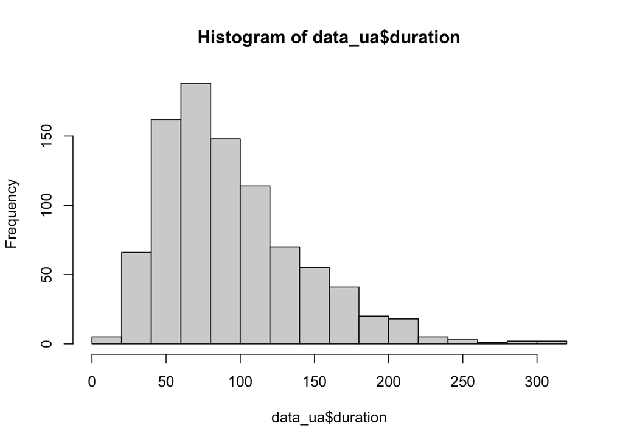

```r
hist(data_ua$duration) # right skew
```

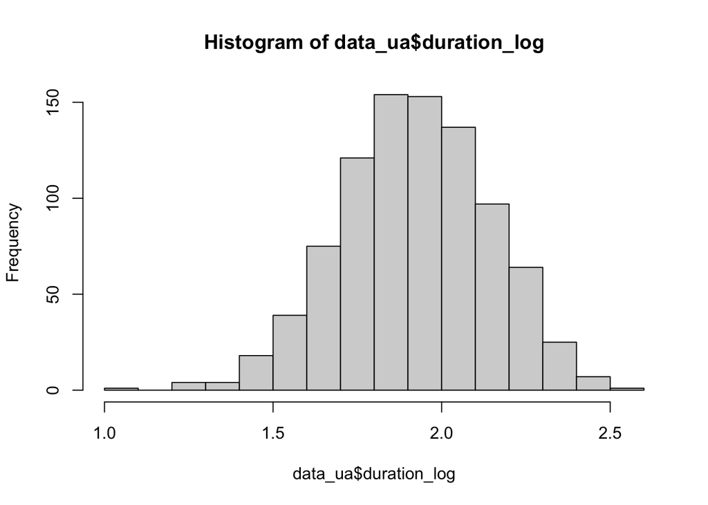

```r
data_ua$duration_log <- log10(data_ua$duration)
hist(data_ua$duration_log) # rougly normally distributed
```

The full model includes Stress, Focus, Vowel and Language as main effects and in interactions.

```r
m_duration0 <- lmer(duration_log ~ stress * focus * language + (1|vowel/word) + (1+stress*language|participant), data = data_ua, REML = FALSE)
Anova(m_duration0, type = "III")
```

```
## Analysis of Deviance Table (Type III Wald chisquare tests)
##
## Response: duration_log
##                           Chisq Df Pr(>Chisq)
## (Intercept)           2807.0720  1    < 2e-16 ***
## stress                  70.5271  1    < 2e-16 ***
## focus                    6.2600  1    0.01235 *
## language                 0.0856  1    0.76985
## stress:focus             1.2883  1    0.25637
## stress:language          0.1291  1    0.71935
## focus:language           0.0231  1    0.87929
## stress:focus:language    0.4708  1    0.49264
## ---
## Signif. codes:  0 '***' 0.001 '**' 0.01 '*' 0.05 '.' 0.1 ' ' 1
```

The model needs to be simplified. We remove non-significant terms: a main effect of Language and a three-way interaction, and fit a reduced model.

```r
m_duration1 <- lmer(duration_log ~ stress * focus + (1|vowel/word) + (1+stress*language|participant), data = data_ua, REML = FALSE)
Anova(m_duration1, type = "III")
```

```
## Analysis of Deviance Table (Type III Wald chisquare tests)
##
## Response: duration_log
##                  Chisq Df Pr(>Chisq)
## (Intercept)  3341.2620  1  < 2.2e-16 ***
## stress        117.6283  1  < 2.2e-16 ***
## focus          10.8984  1  0.0009625 ***
## stress:focus    4.9683  1  0.0258158 *
## ---
## Signif. codes:  0 '***' 0.001 '**' 0.01 '*' 0.05 '.' 0.1 ' ' 1
```

Compare two models. The three-way interaction does not result in a better fit so we select the reduced model m_duration1.

```r
anova(m_duration0, m_duration1)
```

```
## Data: data_ua
## Models:
## m_duration1: duration_log ~ stress * focus + (1 | vowel/word) + (1 + stress * language | participant)
## m_duration0: duration_log ~ stress * focus * language + (1 | vowel/word) + (1 + stress * language | participant)
##             npar     AIC     BIC logLik -2*log(L)  Chisq Df Pr(>Chisq)
## m_duration1   17 -1131.9 -1050.3 582.97   -1165.9
## m_duration0   21 -1125.1 -1024.2 583.54   -1167.1 1.1287  4     0.8897
```

Check if residuals are normally distributed.

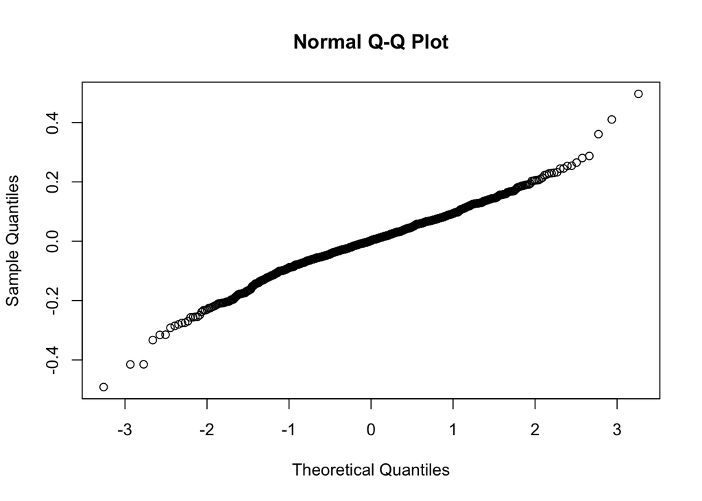

```r
qqnorm(resid(m_duration1)) # OK
```

This is our final model.

```r
m_duration1 -> model_duration_final
summary(model_duration_final)
```

```
## Linear mixed model fit by maximum likelihood  ['lmerMod']
## Formula: duration_log ~ stress * focus + (1 | vowel/word) + (1 + stress *
##     language | participant)
##    Data: data_ua
##
##       AIC       BIC    logLik -2*log(L)  df.resid
##   -1131.9   -1050.3     583.0   -1165.9       883
##
## Scaled residuals:
##     Min      1Q  Median      3Q     Max
## -4.4090 -0.5146  0.0207  0.5949  4.4542
##
## Random effects:
##  Groups      Name                 Variance Std.Dev. Corr
##  word:vowel  (Intercept)          0.005693 0.07545
##  participant (Intercept)          0.006204 0.07877
##              stressWSW            0.002871 0.05358  -0.23
##              languagede           0.004863 0.06974  -0.12 -0.08
##              stressWSW:languagede 0.004517 0.06721   0.40 -0.44 -0.81
##  vowel       (Intercept)          0.001308 0.03617
##  Residual                         0.012425 0.11147
## Number of obs: 900, groups:  word:vowel, 82; participant, 13; vowel, 5
##
## Fixed effects:
##                        Estimate Std. Error t value
## (Intercept)             1.76442    0.03052  57.804
## stressWSW               0.24661    0.02274  10.846
## focusfocused            0.03526    0.01068   3.301
## stressWSW:focusfocused  0.03339    0.01498   2.229
##
## Correlation of Fixed Effects:
##             (Intr) strWSW fcsfcs
## stressWSW   -0.319
## focusfocusd -0.168  0.215
## strssWSW:fc  0.120 -0.320 -0.712
```

Post-hoc comparisons:

```r
emmeans(model_duration_final, pairwise ~ stress | focus)
```

```
## $emmeans
## focus = unfocused:
##  stress emmean     SE   df lower.CL upper.CL
##  SWW      1.76 0.0326 19.6     1.70     1.83
##  WSW      2.01 0.0340 19.7     1.94     2.08
##
## focus = focused:
##  stress emmean     SE   df lower.CL upper.CL
##  SWW      1.80 0.0327 19.8     1.73     1.87
##  WSW      2.08 0.0340 19.6     2.01     2.15
##
## Degrees-of-freedom method: kenward-roger
## Confidence level used: 0.95
##
## $contrasts
## focus = unfocused:
##  contrast  estimate     SE   df t.ratio p.value
##  SWW - WSW   -0.247 0.0237 64.0 -10.415  <.0001
##
## focus = focused:
##  contrast  estimate     SE   df t.ratio p.value
##  SWW - WSW   -0.280 0.0238 64.8 -11.772  <.0001
##
## Degrees-of-freedom method: kenward-roger
```

Back-transform duration to msec and compute ratios (stressed vs unstessed) per focus condition.

```r
em_dur_stress <- as.data.frame(emmeans(model_duration_final, ~ stress | focus)) %>%
  mutate(back = 10^emmean) # back transform to numeric scale (msec)

ratio_table <- em_dur_stress %>%
  select(focus, stress, back) %>%
  tidyr::pivot_wider(names_from = stress, values_from = back) %>%
  mutate(ratio_WSW_SWW = WSW / SWW) # compute ratios

ratio_table
```

```
## # A tibble: 2 × 4
##   focus       SWW   WSW ratio_WSW_SWW
##   <fct>     <dbl> <dbl>         <dbl>
## 1 unfocused  58.1  103.          1.76
## 2 focused    63.0  120.          1.91
```

Plot the final model.

```r
mydf <- ggpredict(
  model_duration_final,
  terms = c("stress", "focus", "language")
)

mydf$stress        <- mydf$x
mydf$focus         <- mydf$group
mydf$language      <- mydf$facet
mydf$pred_duration <- mydf$predicted
```

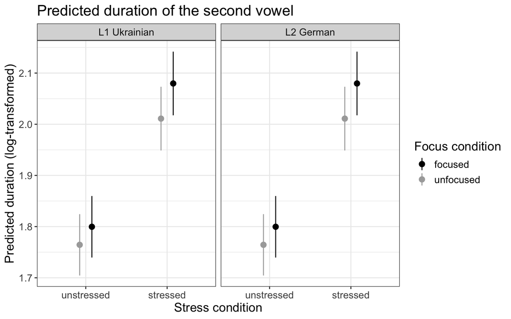

```r
duration <- ggplot(
  mydf,
  aes(x = stress, y = pred_duration, colour = focus)
) +
  geom_pointrange(
    aes(ymin = conf.low, ymax = conf.high),
    position = position_dodge(width = 0.3)
  ) +
  facet_wrap(
    ~ language,
    labeller = as_labeller(c(
      "ua" = "L1 Ukrainian",
      "de" = "L2 German"
    ))
  ) +
  theme_bw() +
  ylab("Predicted duration (log-transformed)") +
  xlab("Stress condition") +
  scale_x_discrete(
    labels = c(
      "SWW" = "unstressed",
      "WSW" = "stressed"
    )
  ) +
  scale_color_manual(
    values = c("focused" = "black", "unfocused" = "darkgray"),
    limits = c("focused", "unfocused"),
    name = "Focus condition"
  ) +
  theme(text = element_text(size = 14)) +
  ggtitle("Predicted duration of the second vowel")
duration
```

## 2.2 L2 German vs L1 German

Log-transform duration in the L1 German subset because it is right-skewed.

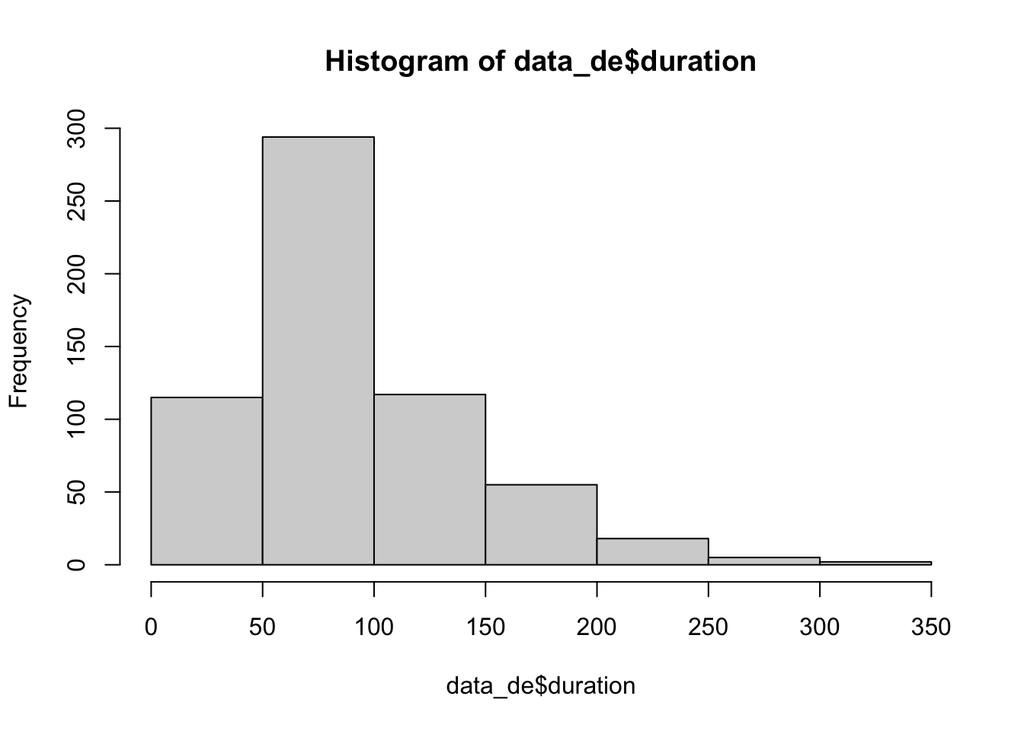

```r
hist(data_de$duration) # right skew
```

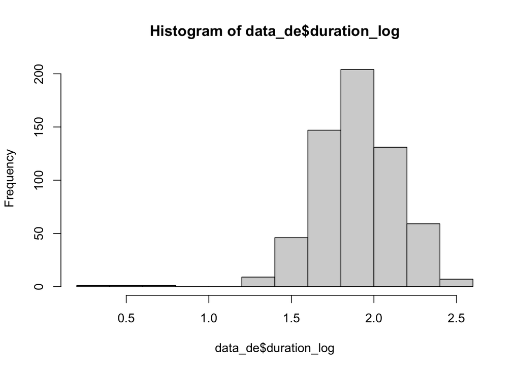

```r
data_de$duration_log <- log10(data_de$duration)
hist(data_de$duration_log) # roughly normal
```

```r
data_de$group <- data_de$language
```

Fit the full lmer model with Stress, Group, Focus as main effects and in two- and three-way interactions.

```r
m_duration_mono0 <- lmer(duration_log ~ stress * group * focus + (1 |vowel/word) + (1+focus|participant), data = data_de)
Anova(m_duration_mono0, type = "III")
```

```
## Analysis of Deviance Table (Type III Wald chisquare tests)
##
## Response: duration_log
##                        Chisq Df Pr(>Chisq)
## (Intercept)        1091.1946  1    < 2e-16 ***
## stress               74.0385  1    < 2e-16 ***
## group                 5.1801  1    0.02285 *
## focus                 3.1129  1    0.07767 .
## stress:group          0.9202  1    0.33743
## stress:focus          2.7985  1    0.09435 .
## group:focus           2.8720  1    0.09013 .
## stress:group:focus    1.6816  1    0.19471
## ---
## Signif. codes:  0 '***' 0.001 '**' 0.01 '*' 0.05 '.' 0.1 ' ' 1
```

We remove the non-significant three-way interaction but test two-way interactions.

```r
m_duration_mono00 <- lmer(duration_log ~ (stress + group + focus)^2 + (1 |vowel/word) + (1+focus|participant), data = data_de)
Anova(m_duration_mono00, type = "III")
```

```
## Analysis of Deviance Table (Type III Wald chisquare tests)
##
## Response: duration_log
##                  Chisq Df Pr(>Chisq)
## (Intercept)  1092.8215  1    < 2e-16 ***
## stress         80.9309  1    < 2e-16 ***
## group           4.1521  1    0.04158 *
## focus           5.6146  1    0.01781 *
## stress:group    0.0081  1    0.92834
## stress:focus    1.3631  1    0.24301
## group:focus     1.2425  1    0.26499
## ---
## Signif. codes:  0 '***' 0.001 '**' 0.01 '*' 0.05 '.' 0.1 ' ' 1
```

Group is significant as a main effect (p = .042) but does not interact with any predictors. We remove interaction terms with Group.

```r
m_duration_group  <- lmer(duration_log ~ stress * focus + group + (1|vowel/word) + (1+focus|participant), data = data_de)
Anova(m_duration_group, type = "III")
```

```
## Analysis of Deviance Table (Type III Wald chisquare tests)
##
## Response: duration_log
##                  Chisq Df Pr(>Chisq)
## (Intercept)  1114.1361  1    < 2e-16 ***
## stress         91.6410  1    < 2e-16 ***
## focus           9.8157  1    0.00173 **
## group           3.0290  1    0.08179 .
## stress:focus    1.3635  1    0.24292
## ---
## Signif. codes:  0 '***' 0.001 '**' 0.01 '*' 0.05 '.' 0.1 ' ' 1
```

The main effect of Group is no longer significant, potentially suggesting Type I error in the previous model (m_duration_mono00). To check this, we fit a model without Group.

```r
m_duration_mono  <- lmer(duration_log ~ stress * focus + (1|vowel/word) + (1|participant), data = data_de)
```

```r
anova(m_duration_mono, m_duration_group)
```

```
## refitting model(s) with ML (instead of REML)
```

```
## Data: data_de
## Models:
## m_duration_mono: duration_log ~ stress * focus + (1 | vowel/word) + (1 | participant)
## m_duration_group: duration_log ~ stress * focus + group + (1 | vowel/word) + (1 + focus | participant)
##                  npar     AIC     BIC logLik -2*log(L)  Chisq Df Pr(>Chisq)
## m_duration_mono     8 -496.64 -461.38 256.32   -512.64
## m_duration_group   11 -495.92 -447.44 258.96   -517.92 5.2768  3     0.1526
```

This is our final model.

```r
summary(m_duration_mono)
```

```
## Linear mixed model fit by REML ['lmerMod']
## Formula: duration_log ~ stress * focus + (1 | vowel/word) + (1 | participant)
##    Data: data_de
##
## REML criterion at convergence: -490.2
##
## Scaled residuals:
##     Min      1Q  Median      3Q     Max
## -6.9199 -0.4702  0.0749  0.5549  3.8783
##
## Random effects:
##  Groups      Name        Variance Std.Dev.
##  word:vowel  (Intercept) 0.009275 0.09631
##  participant (Intercept) 0.009245 0.09615
##  vowel       (Intercept) 0.007108 0.08431
##  Residual                0.019997 0.14141
## Number of obs: 606, groups:  word:vowel, 55; participant, 18; vowel, 5
##
## Fixed effects:
##                        Estimate Std. Error t value
## (Intercept)             1.70045    0.04958  34.300
## stressWSW               0.28453    0.02983   9.538
## focusfocused            0.05315    0.01663   3.197
## stressWSW:focusfocused  0.02799    0.02324   1.205
##
## Correlation of Fixed Effects:
##             (Intr) strWSW fcsfcs
## stressWSW   -0.310
## focusfocusd -0.176  0.276
## strssWSW:fc  0.125 -0.406 -0.711
```

# 3 Intensity

Full model includes Stress, Focus, Vowel and Language as main effects and in interactions.

```r
m_intensity0 <- lmer(intensity ~ stress * language * focus + (1|vowel/word) + (1+stress|participant), data = data_ua, REML = FALSE)
Anova(m_intensity0, type = "III")
```

```
## Analysis of Deviance Table (Type III Wald chisquare tests)
##
## Response: intensity
##                          Chisq Df Pr(>Chisq)
## (Intercept)           273.8648  1  < 2.2e-16 ***
## stress                 13.2718  1  0.0002694 ***
## language               22.4719  1  2.132e-06 ***
## focus                   9.6602  1  0.0018830 **
## stress:language         0.0971  1  0.7552829
## stress:focus           16.5689  1  4.692e-05 ***
## language:focus          0.9801  1  0.3221772
## stress:language:focus   2.0046  1  0.1568235
## ---
## Signif. codes:  0 '***' 0.001 '**' 0.01 '*' 0.05 '.' 0.1 ' ' 1
```

We remove the non-significant three-way interaction but test two-way interactions.

```r
m_intensity00 <- lmer(intensity ~ (stress + language + focus) ^2 + (1|vowel/word) + (1 + stress|participant), data = data_ua, REML = FALSE)
Anova(m_intensity00, type = "III")
```

```
## Analysis of Deviance Table (Type III Wald chisquare tests)
##
## Response: intensity
##                    Chisq Df Pr(>Chisq)
## (Intercept)     272.4552  1  < 2.2e-16 ***
## stress           17.0372  1  3.665e-05 ***
## language         28.0329  1  1.193e-07 ***
## focus            19.0515  1  1.272e-05 ***
## stress:language   0.8235  1   0.364146
## stress:focus     18.3250  1  1.862e-05 ***
## language:focus    8.0386  1   0.004579 **
## ---
## Signif. codes:  0 '***' 0.001 '**' 0.01 '*' 0.05 '.' 0.1 ' ' 1
```

```r
anova(m_intensity0, m_intensity00)
```

```
## Data: data_ua
## Models:
## m_intensity00: intensity ~ (stress + language + focus)^2 + (1 | vowel/word) + (1 + stress | participant)
## m_intensity0: intensity ~ stress * language * focus + (1 | vowel/word) + (1 + stress | participant)
##               npar    AIC    BIC  logLik -2*log(L)  Chisq Df Pr(>Chisq)
## m_intensity00   13 5122.4 5184.9 -2548.2    5096.4
## m_intensity0    14 5122.4 5189.7 -2547.2    5094.4 1.9991  1     0.1574
```

We remove the interaction term Stress x Language because it was not significant.

```r
m_intensity1 <- lmer(intensity ~ (stress + language) * focus + (1|vowel/word) + (1 + stress|participant), data = data_ua, REML = FALSE)
Anova(m_intensity1, type = "III")
```

```
## Analysis of Deviance Table (Type III Wald chisquare tests)
##
## Response: intensity
##                   Chisq Df Pr(>Chisq)
## (Intercept)    277.7132  1  < 2.2e-16 ***
## stress          22.2633  1  2.377e-06 ***
## language        39.2823  1  3.668e-10 ***
## focus           19.2034  1  1.175e-05 ***
## stress:focus    18.2510  1  1.936e-05 ***
## language:focus   8.1553  1   0.004293 **
## ---
## Signif. codes:  0 '***' 0.001 '**' 0.01 '*' 0.05 '.' 0.1 ' ' 1
```

```r
summary(m_intensity1)
```

```
## Linear mixed model fit by maximum likelihood  ['lmerMod']
## Formula: intensity ~ (stress + language) * focus + (1 | vowel/word) +
##     (1 + stress | participant)
##    Data: data_ua
##
##       AIC       BIC    logLik -2*log(L)  df.resid
##    5121.2    5178.9   -2548.6    5097.2       888
##
## Scaled residuals:
##     Min      1Q  Median      3Q     Max
## -3.6863 -0.5581  0.0804  0.5984  2.9387
##
## Random effects:
##  Groups      Name        Variance Std.Dev. Corr
##  word:vowel  (Intercept)   6.1385  2.478
##  participant (Intercept) 108.8234 10.432
##              stressWSW     0.1681  0.410   -0.66
##  vowel       (Intercept)   0.4584  0.677
##  Residual                 13.0840  3.617
## Number of obs: 900, groups:  word:vowel, 82; participant, 13; vowel, 5
##
## Fixed effects:
##                         Estimate Std. Error t value
## (Intercept)              49.3464     2.9611  16.665
## stressWSW                 3.0097     0.6379   4.718
## languagede                4.0878     0.6522   6.268
## focusfocused              1.8229     0.4160   4.382
## stressWSW:focusfocused    2.0723     0.4851   4.272
## languagede:focusfocused  -1.3867     0.4856  -2.856
##
## Correlation of Fixed Effects:
##             (Intr) strWSW langgd fcsfcs stWSW:
## stressWSW   -0.219
## languagede  -0.106 -0.009
## focusfocusd -0.066  0.203  0.201
## strssWSW:fc  0.039 -0.369  0.004 -0.589
## lnggd:fcsfc  0.037  0.004 -0.374 -0.557 -0.002
```

Compare the models with and without interaction as a sanity check. As expected, the added interaction in m_intensity00 does not improve fit so we choose the simpler model, i.e. m_intensity1.

```r
anova(m_intensity00, m_intensity1)
```

```
## Data: data_ua
## Models:
## m_intensity1: intensity ~ (stress + language) * focus + (1 | vowel/word) + (1 + stress | participant)
## m_intensity00: intensity ~ (stress + language + focus)^2 + (1 | vowel/word) + (1 + stress | participant)
##               npar    AIC    BIC  logLik -2*log(L)  Chisq Df Pr(>Chisq)
## m_intensity1    12 5121.2 5178.9 -2548.6    5097.2
## m_intensity00   13 5122.4 5184.9 -2548.2    5096.4 0.8215  1     0.3647
```

Check if residuals are normally distributed.

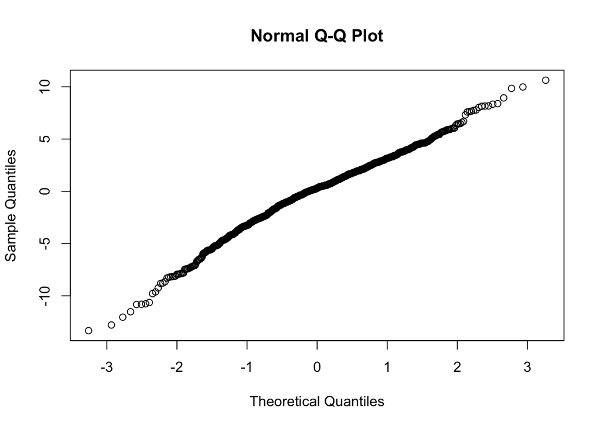

```r
qqnorm(resid(m_intensity1)) # OK
```

This is our final model:

```r
m_intensity1 -> model_intensity_final
summary(model_intensity_final)
```

```
## Linear mixed model fit by maximum likelihood  ['lmerMod']
## Formula: intensity ~ (stress + language) * focus + (1 | vowel/word) +
##     (1 + stress | participant)
##    Data: data_ua
##
##       AIC       BIC    logLik -2*log(L)  df.resid
##    5121.2    5178.9   -2548.6    5097.2       888
##
## Scaled residuals:
##     Min      1Q  Median      3Q     Max
## -3.6863 -0.5581  0.0804  0.5984  2.9387
##
## Random effects:
##  Groups      Name        Variance Std.Dev. Corr
##  word:vowel  (Intercept)   6.1385  2.478
##  participant (Intercept) 108.8234 10.432
##              stressWSW     0.1681  0.410   -0.66
##  vowel       (Intercept)   0.4584  0.677
##  Residual                 13.0840  3.617
## Number of obs: 900, groups:  word:vowel, 82; participant, 13; vowel, 5
##
## Fixed effects:
##                         Estimate Std. Error t value
## (Intercept)              49.3464     2.9611  16.665
## stressWSW                 3.0097     0.6379   4.718
## languagede                4.0878     0.6522   6.268
## focusfocused              1.8229     0.4160   4.382
## stressWSW:focusfocused    2.0723     0.4851   4.272
## languagede:focusfocused  -1.3867     0.4856  -2.856
##
## Correlation of Fixed Effects:
##             (Intr) strWSW langgd fcsfcs stWSW:
## stressWSW   -0.219
## languagede  -0.106 -0.009
## focusfocusd -0.066  0.203  0.201
## strssWSW:fc  0.039 -0.369  0.004 -0.589
## lnggd:fcsfc  0.037  0.004 -0.374 -0.557 -0.002
```

Post-hoc comparisons:

```r
em_int_stress <- as.data.frame(emmeans(model_intensity_final, ~ focus | stress + language))

emmeans(model_intensity_final, pairwise ~ stress | focus + language)
```

```
## $emmeans
## focus = unfocused, language = ua:
##  stress emmean   SE   df lower.CL upper.CL
##  SWW      49.3 3.08 15.2     42.8     55.9
##  WSW      52.4 3.00 15.2     46.0     58.7
##
## focus = focused, language = ua:
##  stress emmean   SE   df lower.CL upper.CL
##  SWW      51.2 3.08 15.2     44.6     57.7
##  WSW      56.3 3.00 15.2     49.9     62.6
##
## focus = unfocused, language = de:
##  stress emmean   SE   df lower.CL upper.CL
##  SWW      53.4 3.08 15.2     46.9     60.0
##  WSW      56.4 3.00 15.3     50.1     62.8
##
## focus = focused, language = de:
##  stress emmean   SE   df lower.CL upper.CL
##  SWW      53.9 3.08 15.2     47.3     60.4
##  WSW      59.0 3.00 15.2     52.6     65.3
##
## Degrees-of-freedom method: kenward-roger
## Confidence level used: 0.95
##
## $contrasts
## focus = unfocused, language = ua:
##  contrast  estimate    SE   df t.ratio p.value
##  SWW - WSW    -3.01 0.649 99.2  -4.638  <.0001
##
## focus = focused, language = ua:
##  contrast  estimate    SE   df t.ratio p.value
##  SWW - WSW    -5.08 0.654 99.6  -7.768  <.0001
##
## focus = unfocused, language = de:
##  contrast  estimate    SE   df t.ratio p.value
##  SWW - WSW    -3.01 0.649 99.2  -4.638  <.0001
##
## focus = focused, language = de:
##  contrast  estimate    SE   df t.ratio p.value
##  SWW - WSW    -5.08 0.654 99.6  -7.768  <.0001
##
## Degrees-of-freedom method: kenward-roger
```

```r
emmeans(model_intensity_final, pairwise ~ focus | language)
```

```
## $emmeans
## language = ua:
##  focus     emmean   SE   df lower.CL upper.CL
##  unfocused   50.9 3.02 14.9     44.4     57.3
##  focused     53.7 3.02 14.9     47.3     60.2
##
## language = de:
##  focus     emmean   SE   df lower.CL upper.CL
##  unfocused   54.9 3.02 15.0     48.5     61.4
##  focused     56.4 3.02 14.9     50.0     62.9
##
## Results are averaged over the levels of: stress
## Degrees-of-freedom method: kenward-roger
## Confidence level used: 0.95
##
## $contrasts
## language = ua:
##  contrast            estimate    SE  df t.ratio p.value
##  unfocused - focused    -2.86 0.337 803  -8.491  <.0001
##
## language = de:
##  contrast            estimate    SE  df t.ratio p.value
##  unfocused - focused    -1.47 0.352 804  -4.189  <.0001
##
## Results are averaged over the levels of: stress
## Degrees-of-freedom method: kenward-roger
```

Compute ratios of stressed versus unstressed vowels per Language and Focus condition.

```r
em_int_stress <- as.data.frame(emmeans(model_intensity_final, ~ stress | language * focus))

ratio_table <- em_int_stress %>%
  select(language, focus, stress, emmean) %>%
  pivot_wider(names_from = stress, values_from = emmean) %>%
  mutate(ratio_WSW_SWW = WSW / SWW)

ratio_table
```

```
## # A tibble: 4 × 5
##   language focus       SWW   WSW ratio_WSW_SWW
##   <fct>    <fct>     <dbl> <dbl>         <dbl>
## 1 ua       unfocused  49.3  52.4          1.06
## 2 de       unfocused  53.4  56.4          1.06
## 3 ua       focused    51.2  56.3          1.10
## 4 de       focused    53.9  59.0          1.09
```

Plot the final model.

```r
mydf_intensity <- ggpredict(model_intensity_final, terms = c("stress", "focus", "language"))

mydf_intensity$stress <- mydf_intensity$x
mydf_intensity$pred_intensity <- mydf_intensity$predicted
mydf_intensity$focus <- mydf_intensity$group
mydf_intensity$language <- mydf_intensity$facet

language_labels <- c("ua" = "L1 Ukrainian", "de" = "L2 German")

mydf_intensity$focus <- factor(
  mydf_intensity$focus,
  levels = c("focused", "unfocused")
)
```

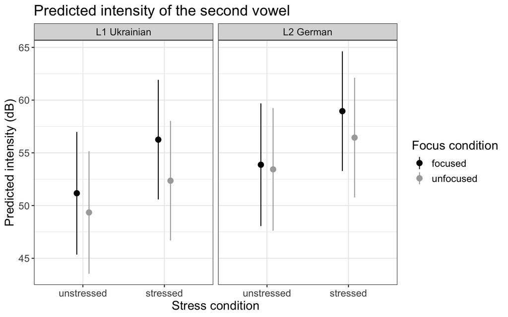

```r
plot_intensity <- ggplot(mydf_intensity, aes(x = stress, y = pred_intensity, colour = focus)) +
  geom_pointrange(aes(ymin = conf.low, ymax = conf.high),
                  position = position_dodge(width = 0.3)) +
  facet_wrap(~language, labeller = labeller(language = language_labels)) +
  theme_bw() +
  ylab("Predicted intensity (dB)") +
  xlab("Stress condition") +
  scale_color_manual(values = c("black", "darkgray"),
                     name = "Focus condition") +
  theme(text = element_text(size = 14)) + scale_x_discrete(
    labels = c(
      "SWW" = "unstressed",
      "WSW" = "stressed"
    )
  ) +
  ggtitle("Predicted intensity of the second vowel")

plot_intensity
```

## 3.1 L2 learners vs German natives

Plot the full lmer model with a three-way interaction.

```r
m_intensity_mono0 <- lmer(intensity ~ stress * focus * group + (1 |vowel/word), data = data_de)
```

```
## boundary (singular) fit: see help('isSingular')
```

We get boundary (singular) fit: see help(‘isSingular’) so we remove nesting.

```r
m_intensity_mono00 <- lmer(intensity ~ stress * focus*group + (1 |word), data = data_de)
Anova(m_intensity_mono00, type = "III")
```

```
## Analysis of Deviance Table (Type III Wald chisquare tests)
##
## Response: intensity
##                        Chisq Df Pr(>Chisq)
## (Intercept)        1974.6287  1    < 2e-16 ***
## stress                3.1043  1    0.07809 .
## focus                 0.9521  1    0.32918
## group                 0.0589  1    0.80820
## stress:focus          0.5216  1    0.47014
## stress:group          0.1285  1    0.71997
## focus:group           0.1404  1    0.70786
## stress:focus:group    0.2509  1    0.61645
## ---
## Signif. codes:  0 '***' 0.001 '**' 0.01 '*' 0.05 '.' 0.1 ' ' 1
```

We remove the non-significant three-way interaction and add by-subject random slopes for Focus.

```r
m_intensity_mono000 <- lmer(intensity ~ (stress + focus + group) ^2 + (1 |word) + (1 + focus | participant), data = data_de)
Anova(m_intensity_mono000, type = "III")
```

```
## Analysis of Deviance Table (Type III Wald chisquare tests)
##
## Response: intensity
##                 Chisq Df Pr(>Chisq)
## (Intercept)  353.1854  1  < 2.2e-16 ***
## stress        11.8796  1  0.0005675 ***
## focus          2.2491  1  0.1336948
## group          0.0050  1  0.9438188
## stress:focus   3.5238  1  0.0604927 .
## stress:group   0.0457  1  0.8307507
## focus:group    2.8554  1  0.0910656 .
## ---
## Signif. codes:  0 '***' 0.001 '**' 0.01 '*' 0.05 '.' 0.1 ' ' 1
```

We remove the non-significant effect of Group and non-significant interactions with Group.

```r
m_intensity_mono <- lmer(intensity ~ stress + focus + (1 |word) + (1 + focus| participant), data = data_de)
Anova(m_intensity_mono, type = "III")
```

```
## Analysis of Deviance Table (Type III Wald chisquare tests)
##
## Response: intensity
##               Chisq Df Pr(>Chisq)
## (Intercept) 513.083  1  < 2.2e-16 ***
## stress       25.035  1  5.631e-07 ***
## focus        16.553  1  4.731e-05 ***
## ---
## Signif. codes:  0 '***' 0.001 '**' 0.01 '*' 0.05 '.' 0.1 ' ' 1
```

We compare the simpler model and the interaction model. The effect of Group (and interactions with group) do not improve fit, suggesting no significant differences between Ukrainian learners and L1 German speakers.

```r
anova(m_intensity_mono, m_intensity_mono000)
```

```
## refitting model(s) with ML (instead of REML)
```

```
## Data: data_de
## Models:
## m_intensity_mono: intensity ~ stress + focus + (1 | word) + (1 + focus | participant)
## m_intensity_mono000: intensity ~ (stress + focus + group)^2 + (1 | word) + (1 + focus | participant)
##                     npar    AIC    BIC  logLik -2*log(L)  Chisq Df Pr(>Chisq)
## m_intensity_mono       8 3514.8 3550.1 -1749.4    3498.8
## m_intensity_mono000   12 3516.2 3569.1 -1746.1    3492.2 6.6144  4     0.1577
```

# 4 F0

Since F0 contours do not develop linearly over time, time-insensitive measures such as minimum, mean, or maximum F0 values may obscure relevant prosodic patterns (Chuang et al., 2021). Therefore, generalized additive mixed models (GAMMs; Hastie & Tibshirani, 1986; Wood, 2017) were used to analyze the differences between F0 contours in different conditions. By modeling non-linear dependencies between the outcome variable (F0) and predictors (Stress, Learner’s Type) over time through smooth functions, GAMMs enable direct comparison of contour shapes using a pre-specified number of base functions.  
Load the German F0 data.

```r
data <- read_tsv("data_exp1_f0.tsv")
```

Turn to factors.

```r
data$Normtime <- data$Ntime
data$participant <- as.factor(data$participant)
data$Normtime <- as.numeric(data$Normtime)
data$stress <- as.factor(data$stress)
data$word <- as.factor(data$word)
data$focus <- as.factor(data$focus)
data$type <- as.factor(data$type)
```

Set an interaction variable Stresstype (factor) representing Stress x Type and check the levels: L1 represents German native speakers, like_ua represents Type-1 learners (who use F0 more like in Ukrainian), like_de represents Type-2 learners (who use F0 more like German natives).

```r
data$stresstype = interaction(data$stress, data$type)
levels(data$stresstype)
```

```
## [1] "SWW.L1"      "WSW.L1"      "SWW.like_de" "WSW.like_de" "SWW.like_ua"
## [6] "WSW.like_ua"
```

Fit a null model without an interaction variable.

```r
nullmodel <- bam(z1 ~ stress + type +s(Normtime, participant, bs="fs", m=1)+s(Normtime, word, bs="fs", m=1), data=data, method="ML")
```

Refit the null model, add random slopes.

```r
nullmodel_slopes <- bam(z1 ~ stress + type + s(Normtime, participant, bs = "fs", m = 1) + s(Normtime, participant, by = stress, bs = "re", m = 1) + s(Normtime, word, bs = "fs", m = 1) + s(Normtime, word, by = type, bs = "re", m = 1), data = data, method = "ML")
```

Compare null models with and without random slopes. We see that random slopes improve fit so we keep them.

```r
compareML(nullmodel,nullmodel_slopes)
```

```
## nullmodel: z1 ~ stress + type + s(Normtime, participant, bs = "fs", m = 1) +
##     s(Normtime, word, bs = "fs", m = 1)
##
## nullmodel_slopes: z1 ~ stress + type + s(Normtime, participant, bs = "fs", m = 1) +
##     s(Normtime, participant, by = stress, bs = "re", m = 1) +
##     s(Normtime, word, bs = "fs", m = 1) + s(Normtime, word, by = type,
##     bs = "re", m = 1)
##
## Chi-square test of ML scores
## -----
##              Model    Score Edf Difference    Df  p.value Sig.
## 1        nullmodel 13082.37   8
## 2 nullmodel_slopes 12902.84  13    179.524 5.000  < 2e-16  ***
##
## AIC difference: 475.31, model nullmodel_slopes has lower AIC.
```

Fit an interaction model (with Stresstype) with random slopes.

```r
# interaction model with random slopes
model1_slopes <- bam(
  z1 ~ stresstype +
    s(Normtime, participant, bs = "fs", m = 1) +
    s(Normtime, participant, by = stress, bs = "re", m = 1) +
    s(Normtime, word, bs = "fs", m = 1) +
    s(Normtime, word, by = type, bs = "re", m = 1),
  data = data,
  method = "ML"
)
```

Compare the interaction model with the null model (with random slopes). As expected, the interaction model improves fit significantly, so we keep the interaction.

```r
compareML(nullmodel_slopes, model1_slopes)
```

```
## nullmodel_slopes: z1 ~ stress + type + s(Normtime, participant, bs = "fs", m = 1) +
##     s(Normtime, participant, by = stress, bs = "re", m = 1) +
##     s(Normtime, word, bs = "fs", m = 1) + s(Normtime, word, by = type,
##     bs = "re", m = 1)
##
## model1_slopes: z1 ~ stresstype + s(Normtime, participant, bs = "fs", m = 1) +
##     s(Normtime, participant, by = stress, bs = "re", m = 1) +
##     s(Normtime, word, bs = "fs", m = 1) + s(Normtime, word, by = type,
##     bs = "re", m = 1)
##
## Chi-square test of ML scores
## -----
##              Model    Score Edf Difference    Df  p.value Sig.
## 1 nullmodel_slopes 12902.84  13
## 2    model1_slopes 12847.27  15     55.574 2.000  < 2e-16  ***
##
## AIC difference: 127.96, model model1_slopes has lower AIC.
```

We fit the model with the number of basis function k=20. This model will be used to get the autocorrelation value (rho).

```r
model1_ml<-bam(z1 ~ stresstype + s(Normtime, by=stresstype, k =20) +s(Normtime, participant, bs="fs", m=1)+s(Normtime, word, bs="fs", m=1) + s(Normtime, participant, by = stress, bs = "re", m = 1) + s(Normtime, word, by = type, bs = "re", m = 1), data=data, method="ML")

summary(model1_ml)
```

```
##
## Family: gaussian
## Link function: identity
##
## Formula:
## z1 ~ stresstype + s(Normtime, by = stresstype, k = 20) + s(Normtime,
##     participant, bs = "fs", m = 1) + s(Normtime, word, bs = "fs",
##     m = 1) + s(Normtime, participant, by = stress, bs = "re",
##     m = 1) + s(Normtime, word, by = type, bs = "re", m = 1)
##
## Parametric coefficients:
##                        Estimate Std. Error t value Pr(>|t|)
## (Intercept)           -0.078248   0.066278  -1.181    0.238
## stresstypeWSW.L1      -0.003382   0.052715  -0.064    0.949
## stresstypeSWW.like_de -0.001688   0.081621  -0.021    0.983
## stresstypeWSW.like_de -0.023046   0.080501  -0.286    0.775
## stresstypeSWW.like_ua -0.008636   0.103067  -0.084    0.933
## stresstypeWSW.like_ua  0.129424   0.096469   1.342    0.180
##
## Approximate significance of smooth terms:
##                                       edf Ref.df      F  p-value
## s(Normtime):stresstypeSWW.L1       14.432  16.68 10.291  < 2e-16 ***
## s(Normtime):stresstypeWSW.L1       14.124  16.41  7.375  < 2e-16 ***
## s(Normtime):stresstypeSWW.like_de  12.282  14.66  8.418  < 2e-16 ***
## s(Normtime):stresstypeWSW.like_de  12.686  15.06  6.660  < 2e-16 ***
## s(Normtime):stresstypeSWW.like_ua  13.267  15.64  5.915  < 2e-16 ***
## s(Normtime):stresstypeWSW.like_ua  12.328  14.71  7.615  < 2e-16 ***
## s(Normtime,participant)           121.276 159.00 47.753  < 2e-16 ***
## s(Normtime,word)                  285.486 359.00 15.321 3.43e-06 ***
## s(Normtime,participant):stressSWW  10.652  15.00 14.377 0.000158 ***
## s(Normtime,participant):stressWSW   3.602  15.00  0.966 0.086303 .
## s(Normtime,word):typeL1            16.745  38.00  1.897 1.44e-05 ***
## s(Normtime,word):typelike_de       23.701  37.00  6.903  < 2e-16 ***
## s(Normtime,word):typelike_ua       28.114  35.00  7.500 1.24e-05 ***
## ---
## Signif. codes:  0 '***' 0.001 '**' 0.01 '*' 0.05 '.' 0.1 ' ' 1
##
## R-sq.(adj) =   0.65   Deviance explained = 66.4%
## -ML =  12424  Scale est. = 0.29789   n = 14212
```

Get autocorrelation.

```r
r_acf <- acf_resid(model1_ml)
```

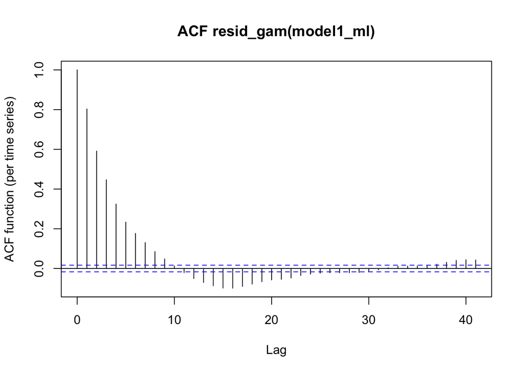

```r
rhoval = r_acf[2]
rhoval
```

```
##         1
## 0.8033716
```

Create an event variable (combining subject and item as a unique identifier) and logical start_event variable (TRUE for start of event, FALSE in all other cases, necessary for autocorrelation in GAMMs), see Wieling (2018).

```r
data$event = interaction(data$participant, data$word)

data$start_event <- "FALSE"
data$start_event[data$Normtime == 1] <- "TRUE"
data$start_event = as.logical(data$start_event)
```

Refit the model with autocorrelation.

```r
#model1_ml_acf<-bam(z1 ~ stresstype + s(Normtime, by=stresstype, k =20) +s(Normtime, participant, bs="fs", m=1)+s(Normtime, word, bs="fs", m=1) + s(Normtime, participant, by = stress, bs = "re", m = 1) + s(Normtime, word, by = type, bs = "re", m = 1), data=data, method="ML", rho = rhoval, AR.start = data$start_event, family = "scat")
```

Check if k is sufficient and increase if necessary.

```r
#gam.check(model1_ml_acf) # no need to increase k
```

Save the model to save computation time.

```r
#saveRDS(model1_ml_acf, file = "model1_ml_acf.rds")
```

Load the saved model.

```r
model1_ml_acf <- readRDS("model1_ml_acf.rds")
```

```r
s <- summary(model1_ml_acf)
```

Difference curves:

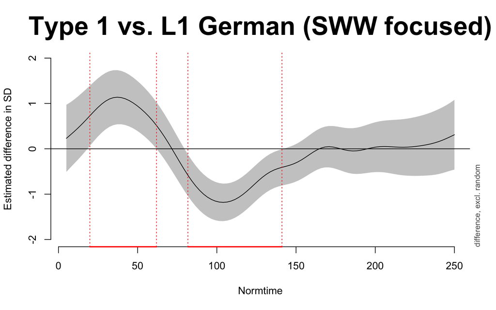

```r
#SWW type 1 vs SWW L1 German
plot_diff(
  model1_ml_acf,
  view = "Normtime",
  comp = list(stresstype = c("SWW.like_ua", "SWW.L1")),
  ylim = c(-2, 2),
  main = "Type 1 vs. L1 German (SWW focused)",
  ylab = "Estimated difference in SD",
  print.summary = FALSE,
  cex.main = 2.5,
)
```

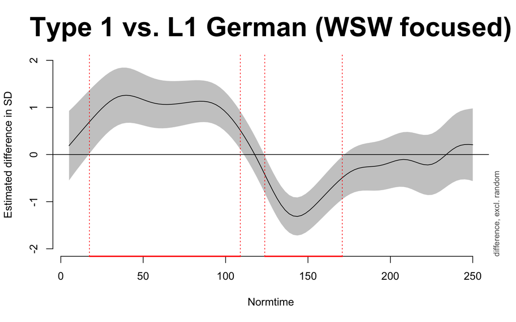

```r
# WSW Type 1 vs L1 German
plot_diff(
  model1_ml_acf,
  view = "Normtime",
  comp = list(stresstype = c("WSW.like_ua", "WSW.L1")),
  ylim = c(-2, 2),
  main = "Type 1 vs. L1 German (WSW focused)",
  ylab = "Estimated difference in SD",
  print.summary = FALSE,
  cex.main = 2.5,
)
```

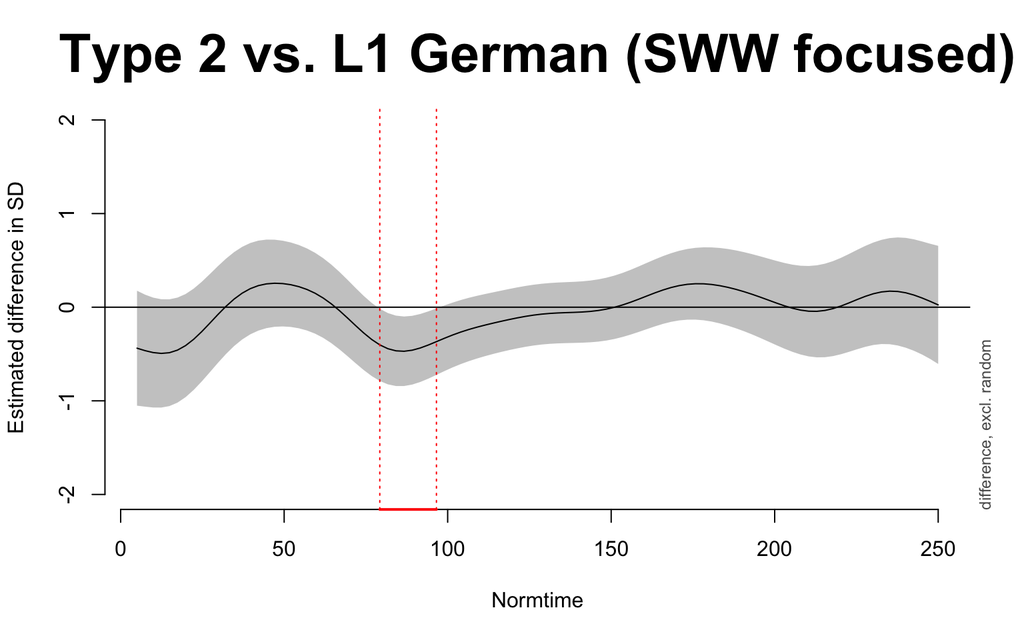

```r
# SWW Type 2 vs L1
plot_diff(
  model1_ml_acf,
  view = "Normtime",
  comp = list(stresstype = c("SWW.like_de", "SWW.L1")),
  ylim = c(-2, 2),
  main = "Type 2 vs. L1 German (SWW focused)",
  ylab = "Estimated difference in SD",
  print.summary = FALSE,
  cex.main = 2.5,
)
```

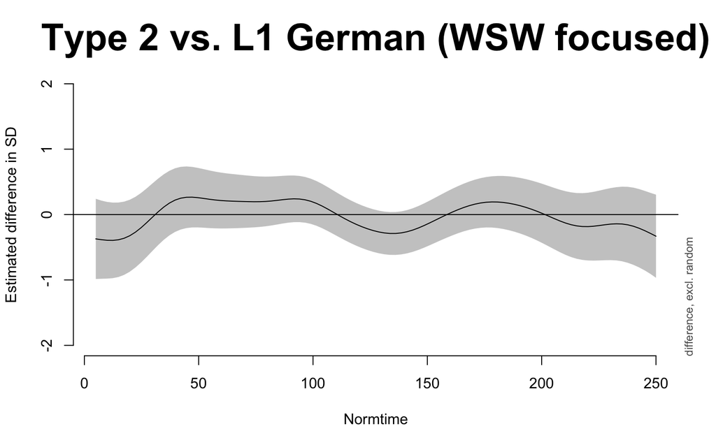

```r
# WSW Type 2 vs L1
plot_diff(
  model1_ml_acf,
  view = "Normtime",
  comp = list(stresstype = c("WSW.like_de", "WSW.L1")),
  ylim = c(-2, 2),
  main = "Type 2 vs. L1 German (WSW focused)",
  ylab = "Estimated difference in SD",
  print.summary = FALSE,
  cex.main = 2.5,
)
```

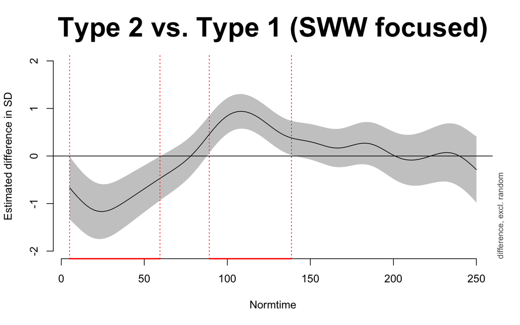

```r
# SWW Type 2 vs Type 1
plot_diff(
  model1_ml_acf,
  view = "Normtime",
  comp = list(stresstype = c("SWW.like_de", "SWW.like_ua")),
  ylim = c(-2, 2),
  main = "Type 2 vs. Type 1 (SWW focused)",
  ylab = "Estimated difference in SD",
  print.summary = FALSE,
  cex.main = 2.5,
)
```

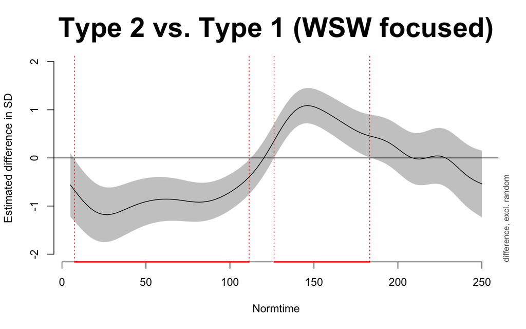

```r
# WSW Type 2 vs Type 1
plot_diff(
  model1_ml_acf,
  view = "Normtime",
  comp = list(stresstype = c("WSW.like_de", "WSW.like_ua")),
  ylim = c(-2, 2),
  main = "Type 2 vs. Type 1 (WSW focused)",
  ylab = "Estimated difference in SD",
  print.summary = FALSE,
  cex.main = 2.5,
)
```

# 5 Duration and Intensity: Type effects?

Finally, we check if duration and intensity interact with Learner’s Type.

```r
data_ua$type <- ifelse(data_ua$participant %in% c("06_4b", "07_1a", "10_1b", "14_3a"), "type1", "type2")
```

Specify the model for duration. We are specifically interested in interactions with Type and assume an interaction between Stress x Focus (as reported previously).

```r
m_duration_type0 <- lmer(duration_log ~ (stress + focus + type)^2 + (1|vowel/word) + (1+language+stress|participant), data = data_ua, REML = FALSE)
Anova(m_duration_type0, type = "III")
```

```
## Analysis of Deviance Table (Type III Wald chisquare tests)
##
## Response: duration_log
##                  Chisq Df Pr(>Chisq)
## (Intercept)  1567.2951  1    < 2e-16 ***
## stress         89.7676  1    < 2e-16 ***
## focus           1.9498  1    0.16261
## type            0.4765  1    0.49002
## stress:focus    4.7749  1    0.02888 *
## stress:type     2.3436  1    0.12580
## focus:type      1.0985  1    0.29460
## ---
## Signif. codes:  0 '***' 0.001 '**' 0.01 '*' 0.05 '.' 0.1 ' ' 1
```

Type was not significant as a main effect and did not interact with any predictors. We refit the model without Type.

```r
m_duration_type <- lmer(duration_log ~ stress*focus + (1|vowel/word) + (1+language+stress|participant), data = data_ua, REML = FALSE)
```

Compare the full and reduced models. The more complex model is not justified.

```r
anova(m_duration_type0, m_duration_type)
```

```
## Data: data_ua
## Models:
## m_duration_type: duration_log ~ stress * focus + (1 | vowel/word) + (1 + language + stress | participant)
## m_duration_type0: duration_log ~ (stress + focus + type)^2 + (1 | vowel/word) + (1 + language + stress | participant)
##                  npar     AIC     BIC logLik -2*log(L)  Chisq Df Pr(>Chisq)
## m_duration_type    13 -1131.1 -1068.7 578.54   -1157.1
## m_duration_type0   16 -1128.7 -1051.8 580.33   -1160.7 3.5749  3     0.3112
```

We repeat the same procedure for Intensity. The full model included three-way interactions.

```r
m_intensity_type0 <- lmer(intensity ~ (type + stress + language + focus)^3 + (1|vowel/word) + (1 + stress|participant), data = data_ua, REML = FALSE)
Anova(m_intensity_type0, type = "III")
```

```
## Analysis of Deviance Table (Type III Wald chisquare tests)
##
## Response: intensity
##                         Chisq Df Pr(>Chisq)
## (Intercept)           86.3115  1  < 2.2e-16 ***
## type                   0.0000  1   0.998665
## stress                 7.5693  1   0.005937 **
## language              31.0022  1  2.577e-08 ***
## focus                  0.3204  1   0.571338
## type:stress            0.0608  1   0.805168
## type:language          9.0248  1   0.002663 **
## type:focus             2.4220  1   0.119639
## stress:language        0.4098  1   0.522091
## stress:focus          17.1578  1  3.440e-05 ***
## language:focus         1.6713  1   0.196081
## type:stress:language   0.2928  1   0.588446
## type:stress:focus      3.6445  1   0.056256 .
## type:language:focus    0.6026  1   0.437579
## stress:language:focus  1.9436  1   0.163275
## ---
## Signif. codes:  0 '***' 0.001 '**' 0.01 '*' 0.05 '.' 0.1 ' ' 1
```

The reduced model included two-way interactions.

```r
m_intensity_type <- lmer(intensity ~ (type + stress + language + focus)^2 + (1|vowel/word) + (1+language|participant), data = data_ua, REML = FALSE)
Anova(m_intensity_type, type = "III")
```

```
## Analysis of Deviance Table (Type III Wald chisquare tests)
##
## Response: intensity
##                   Chisq Df Pr(>Chisq)
## (Intercept)     87.5178  1  < 2.2e-16 ***
## type             0.0041  1   0.949186
## stress          18.4463  1  1.748e-05 ***
## language        24.2356  1  8.524e-07 ***
## focus            5.3947  1   0.020198 *
## type:stress      1.3645  1   0.242766
## type:language    4.6652  1   0.030780 *
## type:focus       2.2097  1   0.137142
## stress:language  1.0525  1   0.304935
## stress:focus    19.5619  1  9.739e-06 ***
## language:focus   9.8199  1   0.001726 **
## ---
## Signif. codes:  0 '***' 0.001 '**' 0.01 '*' 0.05 '.' 0.1 ' ' 1
```

Type is not significant as a main effect, interacts with language, but, crucially, not with Stress or Focus. We remove non-signiciant effects from the model. We leave the effect Type because it is a part of a higher-order interaction.

```r
m_intensity_type_final <- lmer(intensity ~ type * language + language * focus + stress * focus + (1|vowel/word) + (1+language|participant), data = data_ua, REML = FALSE)
Anova(m_intensity_type_final, type = "III")
```

```
## Analysis of Deviance Table (Type III Wald chisquare tests)
##
## Response: intensity
##                  Chisq Df Pr(>Chisq)
## (Intercept)    88.9939  1  < 2.2e-16 ***
## type            0.0056  1   0.940596
## language       24.8134  1  6.316e-07 ***
## focus          21.2957  1  3.936e-06 ***
## stress         22.7186  1  1.875e-06 ***
## type:language   4.4458  1   0.034988 *
## language:focus  9.6514  1   0.001892 **
## focus:stress   19.1049  1  1.237e-05 ***
## ---
## Signif. codes:  0 '***' 0.001 '**' 0.01 '*' 0.05 '.' 0.1 ' ' 1
```

We compare the models. The more complex model (where Type interacts with Stress and Focus) is not justified.

```r
anova(m_intensity_type, m_intensity_type_final)
```

```
## Data: data_ua
## Models:
## m_intensity_type_final: intensity ~ type * language + language * focus + stress * focus + (1 | vowel/word) + (1 + language | participant)
## m_intensity_type: intensity ~ (type + stress + language + focus)^2 + (1 | vowel/word) + (1 + language | participant)
##                        npar    AIC    BIC  logLik -2*log(L) Chisq Df Pr(>Chisq)
## m_intensity_type_final   14 5094.5 5161.8 -2533.3    5066.5
## m_intensity_type         17 5096.0 5177.6 -2531.0    5062.0 4.563  3     0.2067
```